# DBSCAN

DBSCAN (Density-Based Spatial Clustering of Applications with Noise) is a density-based clustering algorithm that groups together points that are closely packed, marking as outliers points that lie alone in low-density regions. Unlike other clustering algorithms, DBSCAN can discover clusters of arbitrary shapes and is particularly effective for identifying outliers.

### Benefits

1. Shape Flexibility: DBSCAN’s most significant advantage is its ability to discover clusters of arbitrary shapes. Unlike many other clustering methods that assume spherical or elliptical cluster shapes, DBSCAN can identify clusters that are elongated, irregular, or have complex boundaries.
2. Automatic Outlier Detection: DBSCAN naturally identifies outliers as noise points
3. No Prior Knowledge of Cluster Count: DBSCAN automatically determines the optimal number of clusters based on the data’s inherent structure.
4. Robustness to Noise: DBSCAN handles noise gracefully by marking outliers. This is a key advantage over other methods that are sensitive to outliers.
5. Density-Based Approach: The algorithm’s focus on density rather than distance-based metrics allows it to identify clusters based on local density patterns.
6. Scalability: DBSCAN achieves O(n log n) time complexity (with proper spatial indexing), making it suitable for moderately large datasets.

### Limitations

1. Parameter Sensitivity: Choice of ε and MinPts significantly affects results
2. Curse of Dimensionality: Performance degrades with high-dimensional data
3. Variable Density: Struggles with clusters of varying densities
4. Border Points: Assignment can be ambiguous for points equidistant from multiple clusters

### Algorithm Steps

1. Randomly select an unvisited point
2. Find all points within ε distance (neighborhood)
3. If the neighborhood contains at least MinPts points, mark as core point and start a new cluster
4. Recursively add all density-reachable points to the cluster
5. Mark points as noise if they cannot be added to any cluster
6. Repeat until all points are visited

## Anomaly Detection Problem

The dataset contains 480 credit card transactions with the following features: - MonthlyTransactionCount: Total number of transactions made by the customer in a month - AverageTransactionValue: Mean dollar amount of the customer’s transactions during the month - OnlineTransactionPercentage: Percentage of the transactions that were conducted online (0 to 100%)

```python
import numpy as np
import pandas as pd
import matplotlib.pyplot as plt
import seaborn as sns
from sklearn.cluster import DBSCAN, KMeans
from sklearn.preprocessing import StandardScaler
from sklearn.decomposition import PCA
from sklearn.metrics import silhouette_score, calinski_harabasz_score
from sklearn.ensemble import IsolationForest
from sklearn.neighbors import LocalOutlierFactor
import warnings
warnings.filterwarnings('ignore')
```

```python
data = pd.read_csv('credit_card_transactions.csv')
data.head()
```

|  | MonthlyTransactionCount | AverageTransactionValue | OnlineTransactionPercentage |
| --- | --- | --- | --- |
| 0 | 78 | 1201 | 15 |
| 1 | 60 | 510 | 23 |
| 2 | 72 | 815 | 25 |
| 3 | 78 | 1192 | 41 |
| 4 | 104 | 1189 | 33 |

```python
data.describe()
```

|  | MonthlyTransactionCount | AverageTransactionValue | OnlineTransactionPercentage |
| --- | --- | --- | --- |
| count | 480.000000 | 480.00000 | 480.000000 |
| mean | 69.958333 | 848.60625 | 56.225000 |
| std | 27.086083 | 321.49736 | 23.385831 |
| min | -15.000000 | 141.00000 | 4.000000 |
| 25% | 51.000000 | 513.00000 | 35.000000 |
| 50% | 70.000000 | 797.00000 | 60.000000 |
| 75% | 89.000000 | 1190.00000 | 74.000000 |
| max | 146.000000 | 1941.00000 | 100.000000 |

## Data Preparation

Key Considerations:

- Numeric Features: DBSCAN is designed for use with numeric data.
- No Missing Data: DBSCAN is sensitive to missing data, so it is best to impute missing data.
- Standardize: Variables with large variance will dominate distance measures.
- Relevant features: Irrelevant or redundant features can muddy cluster patterns.

```python
from sklearn.preprocessing import StandardScaler
scaler = StandardScaler()
scaled_data = scaler.fit_transform(data)
scaled_data[:5,:]
```

```
array([[ 0.29720268,  1.0972451 , -1.76465871],
       [-0.36803856, -1.05431509, -1.42221433],
       [ 0.0754556 , -0.10463946, -1.33660323],
       [ 0.29720268,  1.06922188, -0.65171447],
       [ 1.2581067 ,  1.05988081, -0.99415885]])
```

## Optimal Parameters

DBSCAN performance heavily depends on parameter selection. Key Parameters:

- eps: controls the neighborhood size. It is the maximum distance between two samples for one to be considered as in the neighborhood of the other.
- min_samples: controls the minimum density required to form a cluster. If `min_samples` is set to a higher value, DBSCAN will find denser clusters, whereas if it is set to a lower value, the found clusters will be more sparse.

Parameters are chosen through a grid search.

For this illustration, we will rely on defaults.

```python
dbscan = DBSCAN()
labels = dbscan.fit_predict(scaled_data)
labels[:10]
```

```
array([0, 1, 2, 0, 0, 0, 0, 2, 1, 0])
```

Parameters can be chosen manually. In this illustration, we try a value of eps and min_samples and evaluate them against silhouette score. Noise points labeled as -1 are removed.

```python
dbscan = DBSCAN(eps = 0.7, min_samples=5)
labels = dbscan.fit_predict(scaled_data)
mask = labels!=-1
silhouette_score(scaled_data[mask], labels[mask])
```

```
0.34876264489970304
```

Now, let us evaluate different combinations of parameters based on their silhouette score. There are three requirements for silhouette score to work

1. Removal of noise: Silhouette score measure quality of clusters for non-anomalous points. Therefore, noise points labeled as -1 by DBSCAN are removed.
2. At least two clusters: DBSCAN solutions with fewer than two clusters are ignored.
3. At least two observations per cluster: Clusters with fewer than two observations are ignored.

```python
sil = []
eps_value = []
for eps in np.arange(0.55,0.8,0.05):
    dbscan = DBSCAN(eps = eps, min_samples=5)
    labels = dbscan.fit_predict(scaled_data)
    if len(set(labels))>=2:    # silhouette score can only be computed if number of clusters is greater than 1
        mask = labels!=-1      # marking noise values for removal
        sil.append(silhouette_score(scaled_data[mask], labels[mask]))
        eps_value.append(eps)
pd.DataFrame({'eps':eps_value, 'sil':sil}).sort_values('sil', ascending=False)
```

|  | eps | sil |
| --- | --- | --- |
| 4 | 0.75 | 0.348763 |
| 3 | 0.70 | 0.348763 |
| 0 | 0.55 | 0.233928 |
| 1 | 0.60 | 0.231629 |
| 2 | 0.65 | 0.229452 |

## Apply DBSCAN

- Clusters are labeled by numbers beginning in 0
- Noise points are labeled as -1

```python
dbscan_tuned = DBSCAN(eps=0.75, min_samples=5)
labels = dbscan_tuned.fit_predict(scaled_data)
# Add cluster labels to the original data for analysis
data['cluster_dbscan'] = labels
data.value_counts('cluster_dbscan')
```

```
cluster_dbscan
 1    306
 0    152
-1     22
Name: count, dtype: int64
```

## Evaluate Performance

If labeled data had been available, anomaly predictions could be evaluated based on classification metrics like accuracy.

## Using K-Means

- As an alternative, we examine a three cluster solution using K-Means.
- Data far away from centroids are identified as outliers.
- To align with DBSCAN coding, these are labeled as -1.

```python
kmeans = KMeans(n_clusters=3, random_state=617)
kmeans_labels = kmeans.fit_predict(scaled_data)
data['cluster_kmeans'] = kmeans_labels

# Calculate distance to nearest cluster center for each point
distances = np.min([np.linalg.norm(scaled_data - center, axis=1)
                   for center in kmeans.cluster_centers_], axis=0)
threshold = np.percentile(distances, 95)  # Top 5% as outliers
data.cluster_kmeans[distances>threshold] = -1
data
```

|  | MonthlyTransactionCount | AverageTransactionValue | OnlineTransactionPercentage | cluster_dbscan | cluster_kmeans |
| --- | --- | --- | --- | --- | --- |
| 0 | 78 | 1201 | 15 | 0 | 1 |
| 1 | 60 | 510 | 23 | 1 | 2 |
| 2 | 72 | 815 | 25 | 1 | 2 |
| 3 | 78 | 1192 | 41 | 0 | 1 |
| 4 | 104 | 1189 | 33 | 0 | 1 |
| ... | ... | ... | ... | ... | ... |
| 475 | 146 | 1562 | 40 | -1 | -1 |
| 476 | 142 | 1795 | 97 | -1 | -1 |
| 477 | 94 | 1848 | 87 | -1 | -1 |
| 478 | 22 | 432 | 82 | 1 | 0 |
| 479 | 16 | 684 | 26 | 1 | 2 |

480 rows × 5 columns

### Comparing Results

```python
data.pivot_table(index = 'cluster_dbscan', columns='cluster_kmeans', aggfunc='size',fill_value=0)
```

| cluster_kmeans cluster_dbscan | -1 | 0 | 1 | 2 |
| --- | --- | --- | --- | --- |
| -1 | 16 | 2 | 0 | 4 |
| 0 | 5 | 2 | 144 | 1 |
| 1 | 3 | 166 | 13 | 124 |

## Visualize Results

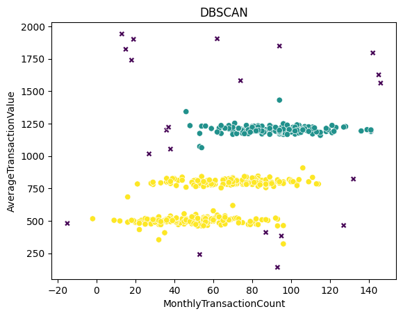

```python
data['noise_dbscan'] = 0
data.noise_dbscan[data.cluster_dbscan==-1] = 1
data.noise_dbscan = data.noise_dbscan.astype('category')
import seaborn as sns
sns.scatterplot(data = data,
                x ='MonthlyTransactionCount',
                y ='AverageTransactionValue',
                hue = 'cluster_dbscan',
                palette='viridis',
                style = 'noise_dbscan',
               legend=False)
plt.title('DBSCAN')
plt.show()
```

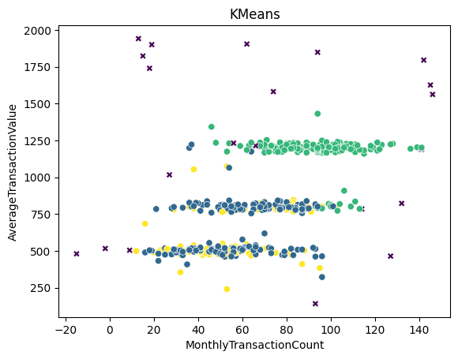

```python
data['noise_kmeans'] = 0
data.noise_kmeans[data.cluster_kmeans==-1] = 1
data.noise_kmeans = data.noise_kmeans.astype('category')
import seaborn as sns
sns.scatterplot(data = data,
                x ='MonthlyTransactionCount',
                y ='AverageTransactionValue',
                hue = 'cluster_kmeans',
                palette='viridis',
                style = 'noise_kmeans',
                legend=False)
plt.title('KMeans')
plt.show()
```

## Summary

In this note, we examined DBSCAN and used it for detecting anomalies in credit card transactions.

This file was generated using Python 3.13.5 on Windows 10 with the following libraries: matplotlib 3.10.3, numpy 2.3.1, pandas 2.3.0, scikit-learn 1.7.1, scipy 1.16.0